# NDFS Contaminants Manuscript

Analyses of Total Concentrations in Water and Zooplankton

Dave Bosworth

September 13, 2023

# Purpose

Run statistical analyses for the total pesticide concentration data in water and zooplankton collected from the Sacramento River (SHR) and Toe Drain (STTD) in the summer-fall periods in 2017, 2018 and 2019. These analyses are included in the NDFS contaminants manuscript.

# Global code and functions

```r
# Load packages
library(tidyverse)
library(rlang)
library(knitr)
library(patchwork)
library(car)
library(emmeans)
library(visreg)
library(here)
library(conflicted)

# Declare package conflict preferences
conflicts_prefer(dplyr::filter(), dplyr::lag())
```

```r
# Check if we are in the correct working directory
i_am("manuscript_contam/src/analysis_contam_conc_water_zoop.Rmd")
```

```
## here() starts at C:/Repositories/04_IEP_Org/ND-FASTR
```

Create function to plot model diagnostics:

```r
# Create model diagnostic plots to check assumptions
plot_model_diag <- function(df_data, param_var, unit_label, model, trans = c("none", "log", "sqrt"), ...) {
  trans <- match.arg(trans)

  df_data <- df_data %>%
    mutate(
      Residuals = resid(model),
      Fitted = predict(model)
    )

  param_name <- as_name(ensym(param_var))

  if (trans == "log") {
    unit_label <- paste0("log[", unit_label, "]")
  } else if (trans == "sqrt") {
    unit_label <- paste0("sqrt[", unit_label, "]")
  }

  plt_hist <- ggplot(df_data, aes(x = Residuals)) +
    geom_histogram(...) +
    labs(
      title = "Residual Histogram",
      x = "Residuals"
    ) +
    theme_bw()

  plt_qq <- ggplot(df_data, aes(sample = Residuals)) +
    labs(
      title = "Residual Probability Plot",
      x = "Normal Quantiles",
      y = "Residuals"
    ) +
    stat_qq() +
    stat_qq_line(linewidth = 1, color = 'red') +
    theme_bw()

  plt_res_fit <- ggplot(df_data, aes(x = Fitted, y = Residuals)) +
    geom_point() +
    labs(
      title = "Residuals vs. Fitted Values",
      x = (paste0("Predicted ", param_name, " (", unit_label, ")")),
      y = paste0("Residuals (", unit_label, ")")
    ) +
    theme_bw()

  plt_obs_fit <- ggplot(df_data, aes(x = Fitted, y = {{ param_var}})) +
    geom_point() +
    geom_abline(slope = 1, intercept = 0, color = "red") +
    labs(
      title = "Observed vs. Fitted Values",
      x = paste0("Predicted ", param_name, " (", unit_label, ")"),
      y = paste0("Observed ", param_name, " (", unit_label, ")")
    ) +
    theme_bw()

  (plt_hist + plt_qq) / (plt_res_fit + plt_obs_fit)
}
```

# Import and Prepare Data

```r
# Define root directory for pesticide data:
fp_pest <- here("manuscript_contam/data/processed")

# Total Pesticide Concentration data:
df_conc_all <- read_rds(file.path(fp_pest, "contam_conc_water_zoop_2017-2019.rds"))

# Pesticide application data:
df_appl <- read_rds(file.path(fp_pest, "pesticide_use_daily_tot_2017-2020.rds"))

# Daily average flow data:
df_davg_flow <- read_rds(here("Water_Quality/Data_Processed/LIS_SR_DailyAvgFlow_2013-2022.rds"))
```

Prepare the pesticide application data to be joined to the concentration data by calculating monthly totals and standardizing to area of the watershed.

```r
df_appl_c <- df_appl %>%
  # Calculate monthly totals by region
  summarize(TotalAppl = sum(TotalApplication), .by = c(Region, Year, Month)) %>%
  mutate(
    # Standardize total application to area (in square miles) of the watershed
    TotalApplStd = if_else(
      Region == "Sacramento River",
      TotalAppl/22526.79948,
      TotalAppl/4217.503529
    ),
    # Define station that each region is assigned to
    Station = case_match(
      Region,
      "Toe Drain" ~ "STTD",
      "Sacramento River" ~ "SHR"
    )
  ) %>%
  # Lag standardized total application data by one month
  arrange(Region, Year, Month) %>%
  group_by(Region) %>%
  mutate(TotalApplStd_lag1 = lag(TotalApplStd, n = 1)) %>%
  ungroup() %>%
  # Clean up dataframe
  select(Station, Year, Month, TotalApplStd, TotalApplStd_lag1)
```

Prepare the flow data to be joined to the concentration data using SR at Freeport flow data for SHR and LIS flow data for STTD. Use Daily Average Net flows for both.

```r
df_davg_flow_c <- df_davg_flow %>%
  select(-LIS_DailyAvgInstFlow) %>%
  pivot_longer(
    cols = ends_with("NetFlow"),
    names_to = "Station",
    values_to = "DailyAvgNetFlow"
  ) %>%
  mutate(
    Station = case_match(
      Station,
      "SR_DailyAvgNetFlow" ~ "SHR",
      "LIS_DailyAvgNetFlow" ~ "STTD"
    )
  )
```

Join pesticide concentration, application, and flow data together.

```r
df_conc_all_c1 <- df_conc_all %>%
  mutate(
    Year = year(Date),
    Month = month(Date, label = TRUE)
  ) %>%
  left_join(df_appl_c, by = join_by(Station, Year, Month)) %>%
  left_join(df_davg_flow_c, by = join_by(Date, Station))

# Look at all data
df_conc_all_c1 %>%
  select(
    Station,
    Date,
    Year,
    starts_with("TotalConc"),
    DailyAvgNetFlow,
    starts_with("TotalAppl")
  ) %>%
  kable()
```

| Station | Date | Year | TotalConc_Zoop | TotalConc_Water | DailyAvgNetFlow | TotalApplStd | TotalApplStd_lag1 |
| --- | --- | --- | --- | --- | --- | --- | --- |
| SHR | 2017-08-29 | 2017 | 227.19872 | 389.42531 | 21200.00 | 3.379151 | 18.641841 |
| SHR | 2017-09-12 | 2017 | 174.19088 | 396.64632 | 22100.00 | 1.440834 | 3.379151 |
| SHR | 2017-09-19 | 2017 | 137.99606 | 147.01557 | 21500.00 | 1.440834 | 3.379151 |
| SHR | 2017-10-03 | 2017 | 316.69620 | 80.32957 | 19400.00 | 2.573115 | 1.440834 |
| SHR | 2017-10-17 | 2017 | 427.37944 | 47.92240 | 11700.00 | 2.573115 | 1.440834 |
| SHR | 2017-11-01 | 2017 | 265.57107 | 97.29594 | 10400.00 | 2.758317 | 2.573115 |
| SHR | 2018-07-12 | 2018 | 218.84885 | 188.76610 | 15700.00 | 17.692933 | 37.851786 |
| SHR | 2018-07-25 | 2018 | 164.99273 | 262.27653 | 16500.00 | 17.692933 | 37.851786 |
| SHR | 2018-08-09 | 2018 | 413.08422 | 668.97693 | 20200.00 | 3.639683 | 17.692933 |
| SHR | 2018-08-23 | 2018 | 302.75363 | 564.30313 | 17500.00 | 3.639683 | 17.692933 |
| SHR | 2018-09-06 | 2018 | 324.04838 | 317.93755 | 18000.00 | 1.435832 | 3.639683 |
| SHR | 2018-09-20 | 2018 | 270.17804 | 151.46644 | 16500.00 | 1.435832 | 3.639683 |
| SHR | 2018-10-11 | 2018 | 651.37113 | 98.85206 | 11600.00 | 2.469192 | 1.435832 |
| SHR | 2018-10-26 | 2018 | 0.00000 | 75.62678 | 9060.00 | 2.469192 | 1.435832 |
| SHR | 2018-11-09 | 2018 | 359.01012 | 198.17201 | 7850.00 | 2.253170 | 2.469192 |
| SHR | 2019-05-21 | 2019 | 127.90884 | 445.48078 | 43200.00 | 15.849626 | 5.706071 |
| SHR | 2019-06-04 | 2019 | 103.08011 | 215.69136 | 44500.00 | 38.770625 | 15.849626 |
| SHR | 2019-06-18 | 2019 | 419.33946 | 505.85984 | 23500.00 | 38.770625 | 15.849626 |
| SHR | 2019-07-02 | 2019 | 129.36941 | 507.56875 | 19300.00 | 19.143787 | 38.770625 |
| SHR | 2019-07-16 | 2019 | 163.66643 | 374.25063 | 17300.00 | 19.143787 | 38.770625 |
| SHR | 2019-08-05 | 2019 | 322.10233 | 337.91232 | 19700.00 | 3.012142 | 19.143787 |
| SHR | 2019-08-19 | 2019 | 386.21467 | 554.08375 | 21000.00 | 3.012142 | 19.143787 |
| SHR | 2019-09-05 | 2019 | 219.43424 | 423.41095 | 22500.00 | 1.578017 | 3.012142 |
| SHR | 2019-09-16 | 2019 | 246.22101 | 331.93137 | 21400.00 | 1.578017 | 3.012142 |
| SHR | 2019-09-30 | 2019 | 418.09428 | 148.04025 | 19000.00 | 1.578017 | 3.012142 |
| SHR | 2019-10-14 | 2019 | 445.06218 | 70.76964 | 12600.00 | 1.125018 | 1.578017 |
| SHR | 2019-10-28 | 2019 | 690.50734 | 90.12275 | 11500.00 | 1.125018 | 1.578017 |
| SHR | 2019-11-13 | 2019 | 378.31172 | 115.52704 | 10100.00 | 2.724691 | 1.125018 |
| SHR | 2019-11-25 | 2019 | 405.88485 | 186.34375 | 11000.00 | 2.724691 | 1.125018 |
| SHR | 2019-12-10 | 2019 | 323.05106 | 558.23809 | 23700.00 | 1.373379 | 2.724691 |
| SHR | 2019-12-27 | 2019 | 326.21796 | 253.96279 | 19500.00 | 1.373379 | 2.724691 |
| STTD | 2017-08-30 | 2017 | 75.15536 |  | 7.64 | 21.114730 | 69.159300 |
| STTD | 2017-09-13 | 2017 | 26.92852 |  | 108.00 | 5.969721 | 21.114730 |
| STTD | 2017-09-20 | 2017 | 73.05093 |  | -75.10 | 5.969721 | 21.114730 |
| STTD | 2017-10-04 | 2017 | 269.00064 |  | -82.80 | 6.902682 | 5.969721 |
| STTD | 2017-10-19 | 2017 | 62.22037 |  | -47.80 | 6.902682 | 5.969721 |
| STTD | 2017-11-02 | 2017 | 285.62279 |  | -29.70 | 12.922356 | 6.902682 |
| STTD | 2018-07-11 | 2018 | 165.58977 |  | -70.50 | 66.033924 | 162.231117 |
| STTD | 2018-07-26 | 2018 | 100.06627 |  | -108.00 | 66.033924 | 162.231117 |
| STTD | 2018-08-08 | 2018 | 64.42045 |  | -70.30 | 21.975841 | 66.033924 |
| STTD | 2018-08-22 | 2018 | 212.96740 |  | -73.70 | 21.975841 | 66.033924 |
| STTD | 2018-08-30 | 2018 | 686.83756 |  | 305.00 | 21.975841 | 66.033924 |
| STTD | 2018-09-05 | 2018 | 1170.56494 |  | 337.00 | 4.200371 | 21.975841 |
| STTD | 2018-09-19 | 2018 | 797.15646 |  | 387.00 | 4.200371 | 21.975841 |
| STTD | 2018-10-10 | 2018 | 83.18350 |  | -93.40 | 9.863104 | 4.200371 |
| STTD | 2018-10-25 | 2018 | 99.33193 |  | -12.00 | 9.863104 | 4.200371 |
| STTD | 2018-11-08 | 2018 | 213.58742 |  | -22.40 | 13.370382 | 9.863104 |
| STTD | 2019-05-20 | 2019 | 919.34468 | 362.10000 | 1270.00 | 85.276308 | 39.939688 |
| STTD | 2019-06-03 | 2019 | 903.77514 | 1467.63536 | 825.00 | 152.302865 | 85.276308 |
| STTD | 2019-06-17 | 2019 | 332.82856 | 899.79820 | 63.30 | 152.302865 | 85.276308 |
| STTD | 2019-07-01 | 2019 | 230.40000 | 607.28115 |  | 67.332801 | 152.302865 |
| STTD | 2019-07-15 | 2019 | 125.70000 | 532.99378 |  | 67.332801 | 152.302865 |
| STTD | 2019-08-07 | 2019 | 0.00000 | 347.24398 | -43.50 | 28.719601 | 67.332801 |
| STTD | 2019-08-21 | 2019 | 89.00000 | 457.27127 | -9.89 | 28.719601 | 67.332801 |
| STTD | 2019-09-04 | 2019 | 641.20000 | 2289.24197 | 598.00 | 7.454874 | 28.719601 |
| STTD | 2019-09-18 | 2019 | 548.00000 | 2093.83725 | 635.00 | 7.454874 | 28.719601 |
| STTD | 2019-10-02 | 2019 | 333.90000 | 766.80342 | -19.60 | 4.366761 | 7.454874 |
| STTD | 2019-10-16 | 2019 | 181.70000 | 347.25295 | -88.70 | 4.366761 | 7.454874 |
| STTD | 2019-10-28 | 2019 | 315.00000 | 233.26624 | -56.50 | 4.366761 | 7.454874 |
| STTD | 2019-11-14 | 2019 | 406.10000 | 164.59963 | -113.00 | 14.037269 | 4.366761 |
| STTD | 2019-11-26 | 2019 | 413.70000 | 193.53662 | 6.97 | 14.037269 | 4.366761 |
| STTD | 2019-12-09 | 2019 | 994.50000 | 1714.24731 | 300.00 | 5.704477 | 14.037269 |
| STTD | 2019-12-26 | 2019 | 373.20000 | 577.11950 | 220.00 | 5.704477 | 14.037269 |

It looks like all of the flow data was available for SHR, but STTD is missing a few flow values in July 2019. We’ll restrict the date ranges to July 1 - Oct 31 for each year since some of the data extends outside of the summer-fall period.

```r
df_conc_all_c2 <- df_conc_all_c1 %>%
  mutate(Month = as.numeric(Month)) %>%
  filter(Month %in% 7:10)

# Look at filtered data
df_conc_all_c2 %>%
  select(
    Station,
    Date,
    Year,
    starts_with("TotalConc"),
    DailyAvgNetFlow,
    starts_with("TotalAppl")
  ) %>%
  kable()
```

| Station | Date | Year | TotalConc_Zoop | TotalConc_Water | DailyAvgNetFlow | TotalApplStd | TotalApplStd_lag1 |
| --- | --- | --- | --- | --- | --- | --- | --- |
| SHR | 2017-08-29 | 2017 | 227.19872 | 389.42531 | 21200.00 | 3.379151 | 18.641841 |
| SHR | 2017-09-12 | 2017 | 174.19088 | 396.64632 | 22100.00 | 1.440834 | 3.379151 |
| SHR | 2017-09-19 | 2017 | 137.99606 | 147.01557 | 21500.00 | 1.440834 | 3.379151 |
| SHR | 2017-10-03 | 2017 | 316.69620 | 80.32957 | 19400.00 | 2.573115 | 1.440834 |
| SHR | 2017-10-17 | 2017 | 427.37944 | 47.92240 | 11700.00 | 2.573115 | 1.440834 |
| SHR | 2018-07-12 | 2018 | 218.84885 | 188.76610 | 15700.00 | 17.692933 | 37.851786 |
| SHR | 2018-07-25 | 2018 | 164.99273 | 262.27653 | 16500.00 | 17.692933 | 37.851786 |
| SHR | 2018-08-09 | 2018 | 413.08422 | 668.97693 | 20200.00 | 3.639683 | 17.692933 |
| SHR | 2018-08-23 | 2018 | 302.75363 | 564.30313 | 17500.00 | 3.639683 | 17.692933 |
| SHR | 2018-09-06 | 2018 | 324.04838 | 317.93755 | 18000.00 | 1.435832 | 3.639683 |
| SHR | 2018-09-20 | 2018 | 270.17804 | 151.46644 | 16500.00 | 1.435832 | 3.639683 |
| SHR | 2018-10-11 | 2018 | 651.37113 | 98.85206 | 11600.00 | 2.469192 | 1.435832 |
| SHR | 2018-10-26 | 2018 | 0.00000 | 75.62678 | 9060.00 | 2.469192 | 1.435832 |
| SHR | 2019-07-02 | 2019 | 129.36941 | 507.56875 | 19300.00 | 19.143787 | 38.770625 |
| SHR | 2019-07-16 | 2019 | 163.66643 | 374.25063 | 17300.00 | 19.143787 | 38.770625 |
| SHR | 2019-08-05 | 2019 | 322.10233 | 337.91232 | 19700.00 | 3.012142 | 19.143787 |
| SHR | 2019-08-19 | 2019 | 386.21467 | 554.08375 | 21000.00 | 3.012142 | 19.143787 |
| SHR | 2019-09-05 | 2019 | 219.43424 | 423.41095 | 22500.00 | 1.578017 | 3.012142 |
| SHR | 2019-09-16 | 2019 | 246.22101 | 331.93137 | 21400.00 | 1.578017 | 3.012142 |
| SHR | 2019-09-30 | 2019 | 418.09428 | 148.04025 | 19000.00 | 1.578017 | 3.012142 |
| SHR | 2019-10-14 | 2019 | 445.06218 | 70.76964 | 12600.00 | 1.125018 | 1.578017 |
| SHR | 2019-10-28 | 2019 | 690.50734 | 90.12275 | 11500.00 | 1.125018 | 1.578017 |
| STTD | 2017-08-30 | 2017 | 75.15536 |  | 7.64 | 21.114730 | 69.159300 |
| STTD | 2017-09-13 | 2017 | 26.92852 |  | 108.00 | 5.969721 | 21.114730 |
| STTD | 2017-09-20 | 2017 | 73.05093 |  | -75.10 | 5.969721 | 21.114730 |
| STTD | 2017-10-04 | 2017 | 269.00064 |  | -82.80 | 6.902682 | 5.969721 |
| STTD | 2017-10-19 | 2017 | 62.22037 |  | -47.80 | 6.902682 | 5.969721 |
| STTD | 2018-07-11 | 2018 | 165.58977 |  | -70.50 | 66.033924 | 162.231117 |
| STTD | 2018-07-26 | 2018 | 100.06627 |  | -108.00 | 66.033924 | 162.231117 |
| STTD | 2018-08-08 | 2018 | 64.42045 |  | -70.30 | 21.975841 | 66.033924 |
| STTD | 2018-08-22 | 2018 | 212.96740 |  | -73.70 | 21.975841 | 66.033924 |
| STTD | 2018-08-30 | 2018 | 686.83756 |  | 305.00 | 21.975841 | 66.033924 |
| STTD | 2018-09-05 | 2018 | 1170.56494 |  | 337.00 | 4.200371 | 21.975841 |
| STTD | 2018-09-19 | 2018 | 797.15646 |  | 387.00 | 4.200371 | 21.975841 |
| STTD | 2018-10-10 | 2018 | 83.18350 |  | -93.40 | 9.863104 | 4.200371 |
| STTD | 2018-10-25 | 2018 | 99.33193 |  | -12.00 | 9.863104 | 4.200371 |
| STTD | 2019-07-01 | 2019 | 230.40000 | 607.28115 |  | 67.332801 | 152.302865 |
| STTD | 2019-07-15 | 2019 | 125.70000 | 532.99378 |  | 67.332801 | 152.302865 |
| STTD | 2019-08-07 | 2019 | 0.00000 | 347.24398 | -43.50 | 28.719601 | 67.332801 |
| STTD | 2019-08-21 | 2019 | 89.00000 | 457.27127 | -9.89 | 28.719601 | 67.332801 |
| STTD | 2019-09-04 | 2019 | 641.20000 | 2289.24197 | 598.00 | 7.454874 | 28.719601 |
| STTD | 2019-09-18 | 2019 | 548.00000 | 2093.83725 | 635.00 | 7.454874 | 28.719601 |
| STTD | 2019-10-02 | 2019 | 333.90000 | 766.80342 | -19.60 | 4.366761 | 7.454874 |
| STTD | 2019-10-16 | 2019 | 181.70000 | 347.25295 | -88.70 | 4.366761 | 7.454874 |
| STTD | 2019-10-28 | 2019 | 315.00000 | 233.26624 | -56.50 | 4.366761 | 7.454874 |

# Zooplankton

```r
# Prepare zooplankton concentration data for analysis
df_zoop <- df_conc_all_c2 %>%
  select(-TotalConc_Water) %>%
  drop_na() %>%
  # Remove two samples with total concentrations equal to zero
  filter(TotalConc_Zoop > 0) %>%
  mutate(
    # Add log-transformed and sqrt-transformed zooplankton concentrations
    TotalConc_Zoop_log = log(TotalConc_Zoop),
    TotalConc_Zoop_sqrt = sqrt(TotalConc_Zoop),
    # Convert year to character for categorical models
    Year = as.character(Year)
  )
```

## Exploratory Plots

Before running the analyses, lets visualize the data.

### Boxplots

First, we’ll look at a boxplot comparing total pesticide concentrations in zooplankton between stations.

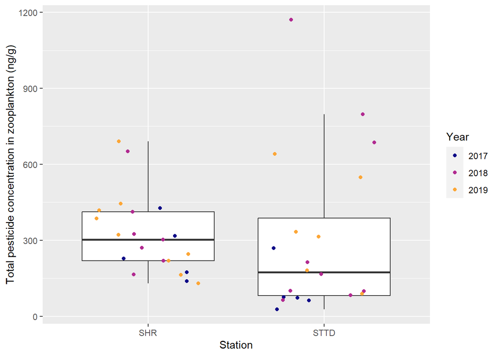

```r
df_zoop %>%
  ggplot(aes(x = Station, y = TotalConc_Zoop)) +
  geom_boxplot(outlier.shape = NA) +
  geom_jitter(aes(color = Year), width = 0.3) +
  scale_color_viridis_d(option = "plasma", end = 0.8) +
  ylab("Total pesticide concentration in zooplankton (ng/g)")
```

SHR has a higher median concentration than STTD, but STTD has some higher values than SHR particularly in 2018. Let’s break apart the boxplot by station and year.

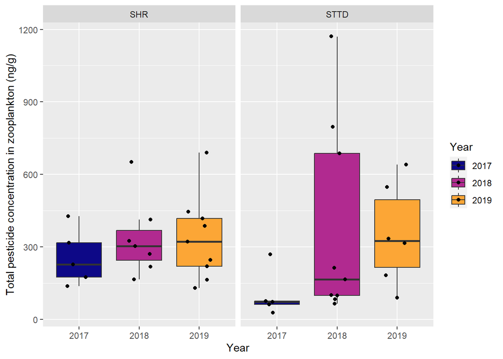

```r
df_zoop %>%
  ggplot(aes(x = Year, y = TotalConc_Zoop, fill = Year)) +
  geom_boxplot(outlier.shape = NA) +
  geom_jitter(width = 0.2) +
  facet_wrap(vars(Station)) +
  scale_fill_viridis_d(option = "plasma", end = 0.8) +
  ylab("Total pesticide concentration in zooplankton (ng/g)")
```

Overall, STTD in 2018 had the highest variation in concentrations. Let’s look at a boxplot grouped only by year.

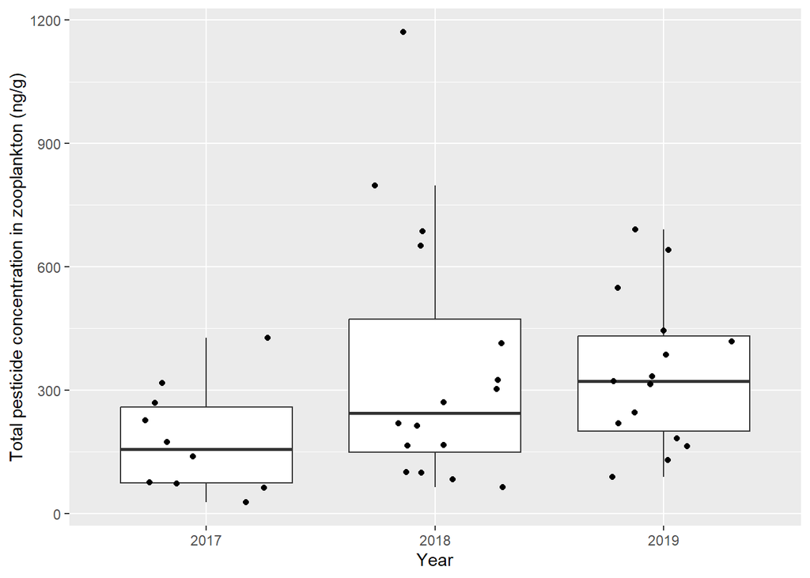

```r
df_zoop %>%
  ggplot(aes(x = Year, y = TotalConc_Zoop)) +
  geom_boxplot(outlier.shape = NA) +
  geom_jitter(width = 0.3) +
  ylab("Total pesticide concentration in zooplankton (ng/g)")
```

The median of total concentrations was slightly higher in 2019 than other years when both stations are grouped together.

### Seasonal time-series

Now, let’s see how total concentrations varied seasonally using day of year for each station and year.

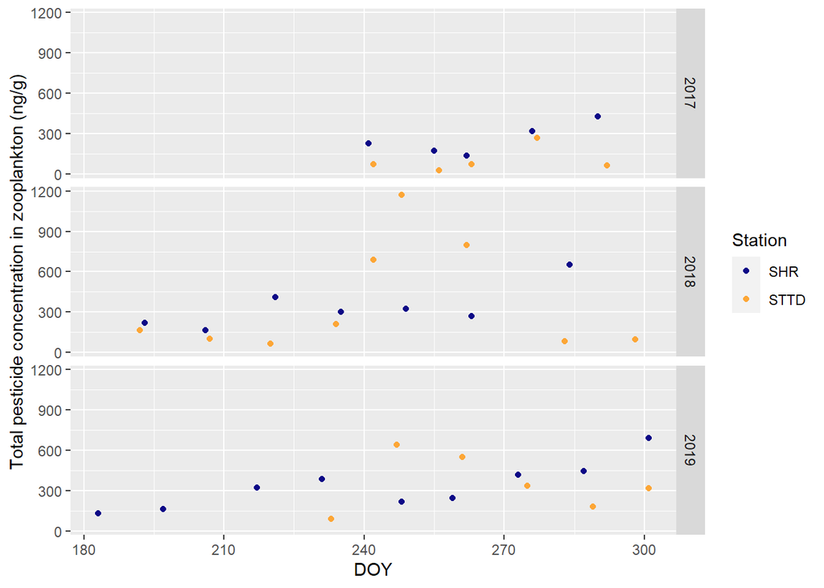

```r
df_zoop %>%
  ggplot(aes(x = yday(Date), y = TotalConc_Zoop, color = Station)) +
  geom_point() +
  facet_grid(rows = vars(Year)) +
  scale_color_viridis_d(option = "plasma", end = 0.8) +
  labs(x = "DOY", y = "Total pesticide concentration in zooplankton (ng/g)")
```

It almost looks like SHR and STTD have opposite seasonal trends.

### Concentration vs Flow

Now, let’s take a look at how the total pesticide concentrations in zooplankton vary with daily average net flow for each station.

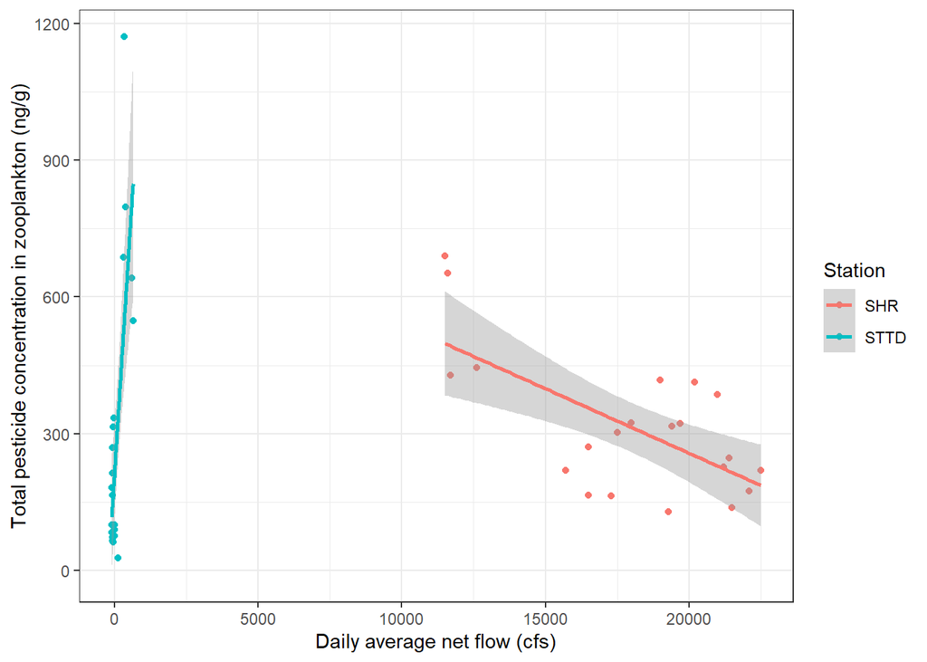

```r
df_zoop %>%
  ggplot(aes(x = DailyAvgNetFlow, y = TotalConc_Zoop, color = Station)) +
  geom_point() +
  geom_smooth(method = "lm", formula = y ~ x) +
  labs(
    x = "Daily average net flow (cfs)",
    y = "Total pesticide concentration in zooplankton (ng/g)"
  ) +
  theme_bw()
```

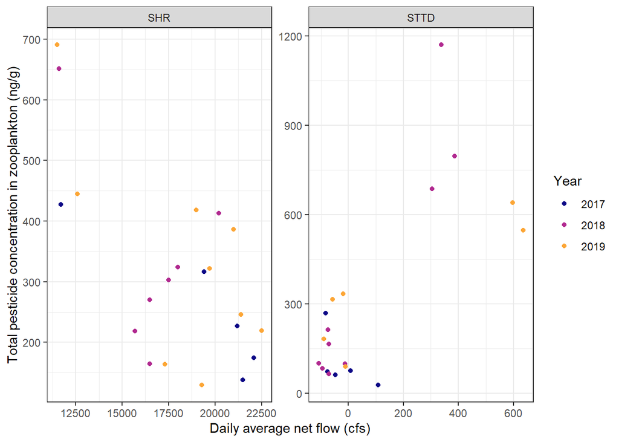

```r
df_zoop %>%
  ggplot(aes(x = DailyAvgNetFlow, y = TotalConc_Zoop, color = Year)) +
  geom_point() +
  scale_color_viridis_d(option = "plasma", end = 0.8) +
  facet_wrap(vars(Station), scales = "free") +
  labs(
    x = "Daily average net flow (cfs)",
    y = "Total pesticide concentration in zooplankton (ng/g)"
  ) +
  theme_bw()
```

SHR seems to have a negative relationship between concentration and flow, while concentrations at STTD seem to have a positive relationship with flow.

### Concentration vs Application

Next, let’s look at the total pesticide concentrations in zooplankton as a function of standardized monthly total application data for each station.

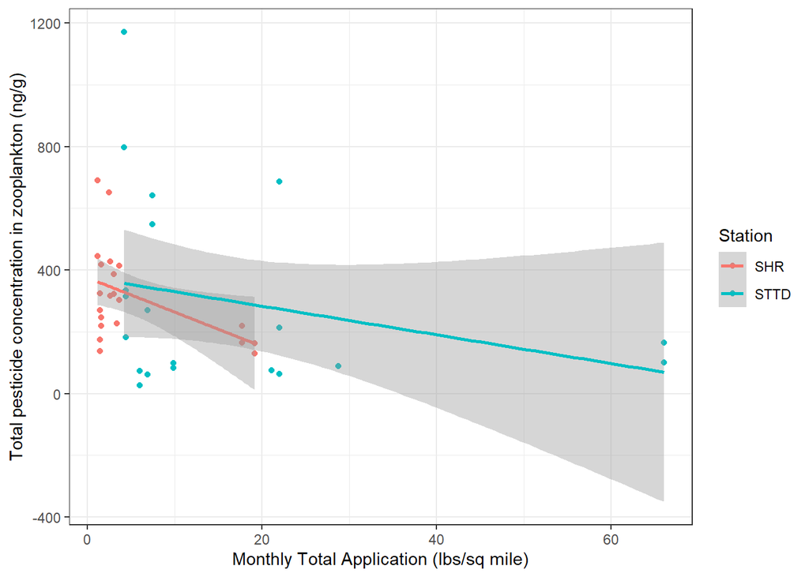

```r
df_zoop %>%
  ggplot(aes(x = TotalApplStd, y = TotalConc_Zoop, color = Station)) +
  geom_point() +
  geom_smooth(method = "lm", formula = y ~ x) +
  labs(
    x = "Monthly Total Application (lbs/sq mile)",
    y = "Total pesticide concentration in zooplankton (ng/g)"
  ) +
  theme_bw()
```

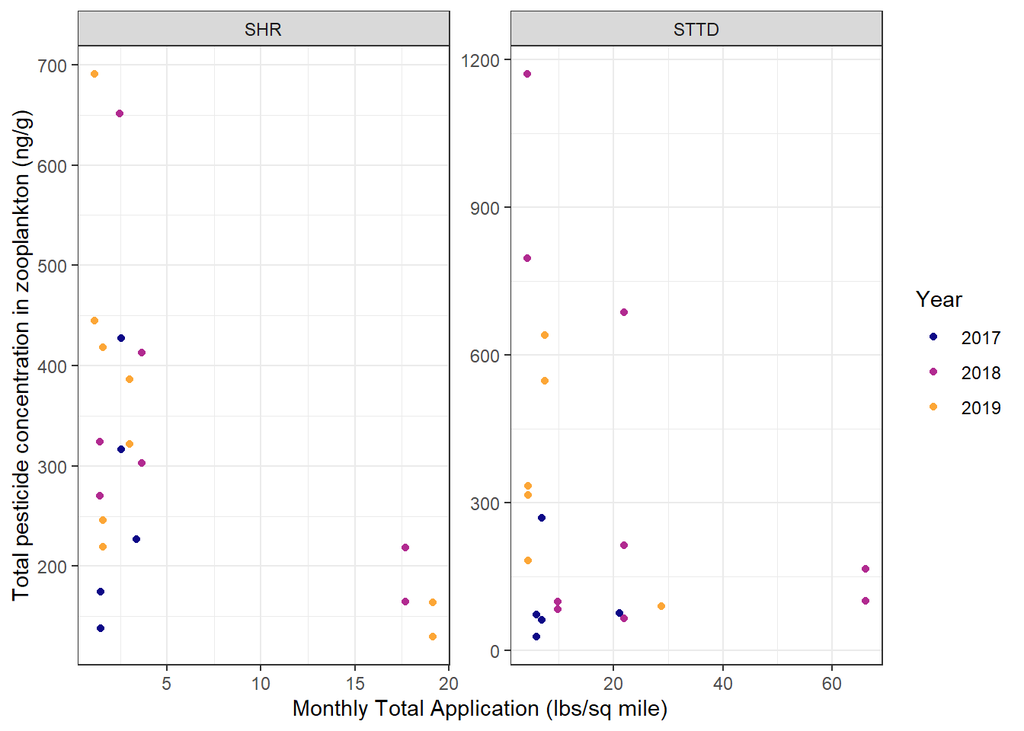

```r
df_zoop %>%
  ggplot(aes(x = TotalApplStd, y = TotalConc_Zoop, color = Year)) +
  geom_point() +
  scale_color_viridis_d(option = "plasma", end = 0.8) +
  facet_wrap(vars(Station), scales = "free") +
  labs(
    x = "Monthly Total Application (lbs/sq mile)",
    y = "Total pesticide concentration in zooplankton (ng/g)"
  ) +
  theme_bw()
```

There appears to be a weak negative relationship between pesticide concentrations in zooplankton and monthly application amounts at both stations. I’m not sure that monthly application will be a good predictor. Let’s take a look at whether using the prior month’s application amount makes a difference.

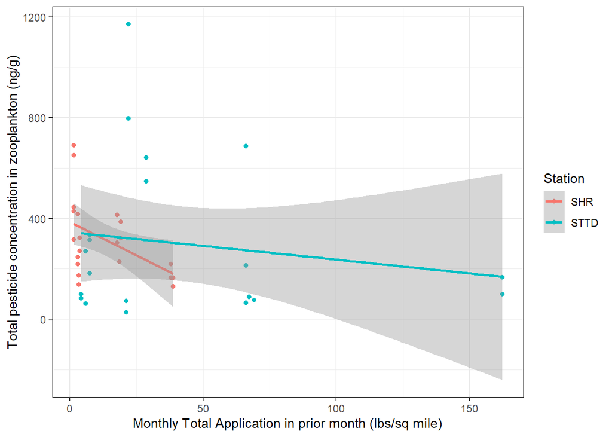

```r
df_zoop %>%
  ggplot(aes(x = TotalApplStd_lag1, y = TotalConc_Zoop, color = Station)) +
  geom_point() +
  geom_smooth(method = "lm", formula = y ~ x) +
  labs(
    x = "Monthly Total Application in prior month (lbs/sq mile)",
    y = "Total pesticide concentration in zooplankton (ng/g)"
  ) +
  theme_bw()
```

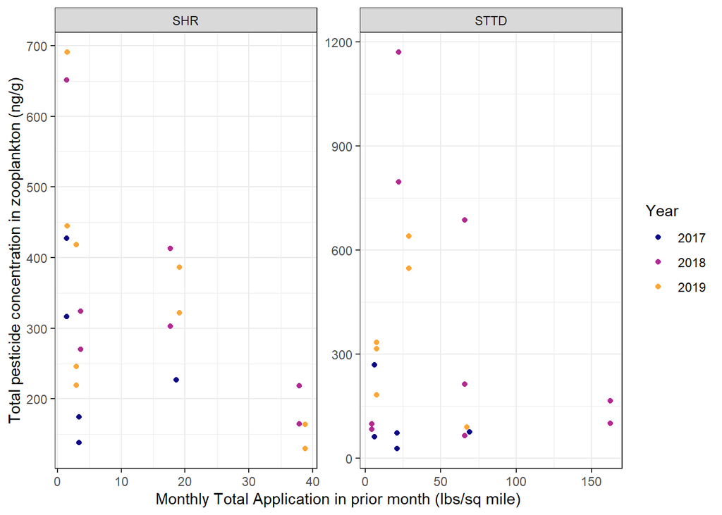

```r
df_zoop %>%
  ggplot(aes(x = TotalApplStd_lag1, y = TotalConc_Zoop, color = Year)) +
  geom_point() +
  scale_color_viridis_d(option = "plasma", end = 0.8) +
  facet_wrap(vars(Station), scales = "free") +
  labs(
    x = "Monthly Total Application in prior month (lbs/sq mile)",
    y = "Total pesticide concentration in zooplankton (ng/g)"
  ) +
  theme_bw()
```

Hmm, not really…

### Histograms

Lastly, let’s take a look at histograms of total pesticide concentrations in zooplankton to look at its distribution. We’ll look at each station separately and then all data grouped together.

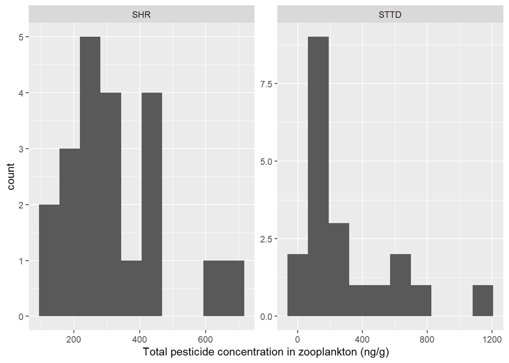

```r
df_zoop %>%
  ggplot(aes(x = TotalConc_Zoop)) +
  geom_histogram(bins = 10) +
  facet_wrap(vars(Station), scales = "free") +
  xlab("Total pesticide concentration in zooplankton (ng/g)")
```

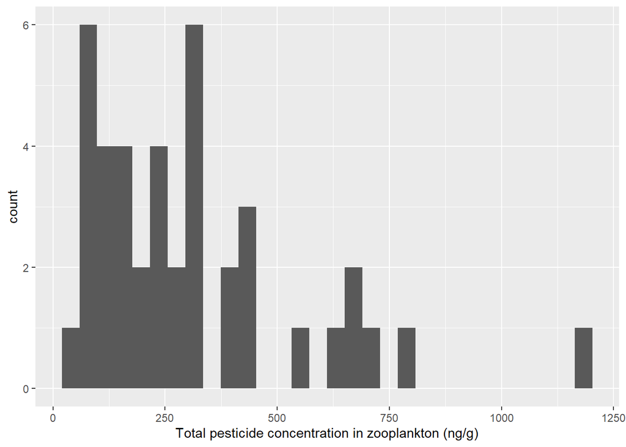

```r
df_zoop %>%
  ggplot(aes(x = TotalConc_Zoop)) +
  geom_histogram() +
  xlab("Total pesticide concentration in zooplankton (ng/g)")
```

We’ll probably need to use transformed zooplankton concentration data for the analyses.

## Analyses

### Models with Flow and Application

We’ll create linear models of the zooplankton concentrations as a function of daily average net flow and monthly pesticide application amounts for each station separately. We’ll start with the original concentration values, but we may need to transform them. These models will allow us to examine:

1. Do total pesticide concentrations in zooplankton significantly respond to flow at either or both SHR and STTD?
2. Do total pesticide concentrations in zooplankton significantly respond to pesticide application at either or both SHR and STTD?

#### SHR

We’ll start with SHR

##### Current month application

```r
df_zoop_shr <- df_zoop %>% filter(Station == "SHR")

m_zoop_q_appl_shr <- df_zoop_shr %>%
  lm(TotalConc_Zoop ~ DailyAvgNetFlow + TotalApplStd, data = .)
```

Plot the diagnostics

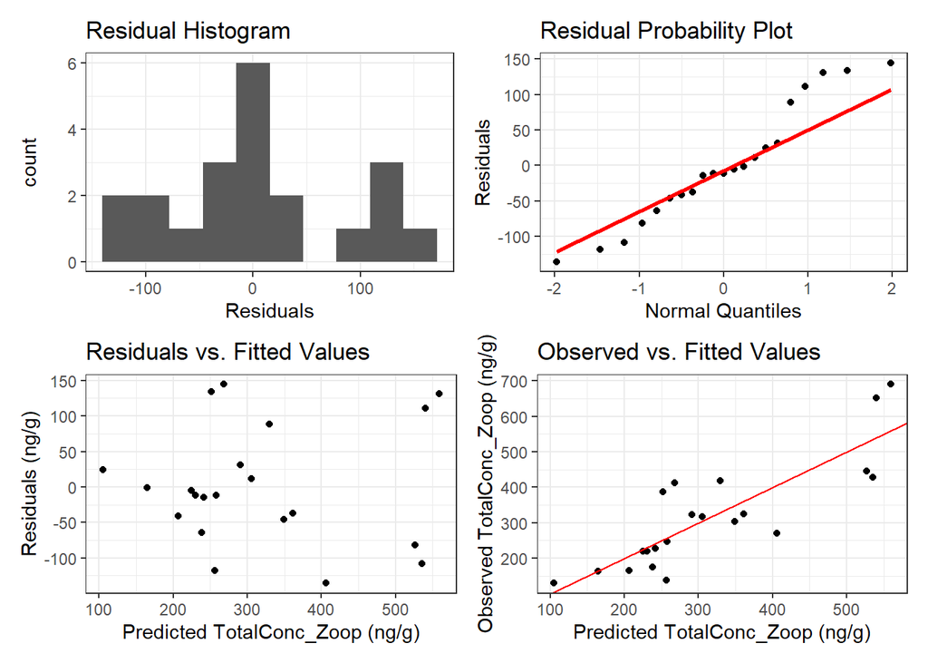

```r
df_zoop_shr %>% plot_model_diag(
  TotalConc_Zoop,
  "ng/g",
  m_zoop_q_appl_shr,
  bins = 10
)
```

```r
shapiro.test(m_zoop_q_appl_shr$residuals)
```

```
##
##  Shapiro-Wilk normality test
##
## data:  m_zoop_q_appl_shr$residuals
## W = 0.94631, p-value = 0.2895
```

The residuals deviate from a normal distribution according to visual inspection. We’ll re-run the model using the natural log transformation.

```r
m_zoop_q_appl_shr_log <- df_zoop_shr %>%
  lm(TotalConc_Zoop_log ~ DailyAvgNetFlow + TotalApplStd, data = .)
```

Plot the diagnostics

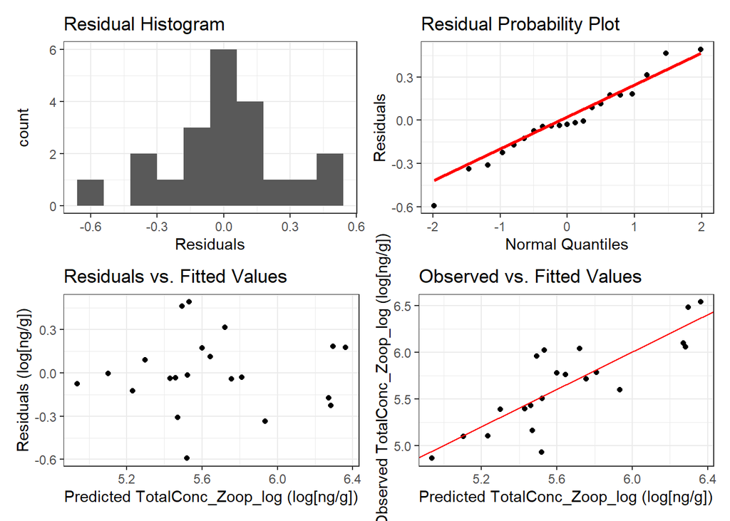

```r
df_zoop_shr %>% plot_model_diag(
  TotalConc_Zoop_log,
  "ng/g",
  m_zoop_q_appl_shr_log,
  trans = "log",
  bins = 10
)
```

```r
shapiro.test(m_zoop_q_appl_shr_log$residuals)
```

```
##
##  Shapiro-Wilk normality test
##
## data:  m_zoop_q_appl_shr_log$residuals
## W = 0.9739, p-value = 0.8169
```

The model diagnostics look pretty good with the log-transformed values, so we’ll take a closer look at this model.

```r
summary(m_zoop_q_appl_shr_log)
```

```
##
## Call:
## lm(formula = TotalConc_Zoop_log ~ DailyAvgNetFlow + TotalApplStd,
##     data = .)
##
## Residuals:
##      Min       1Q   Median       3Q      Max
## -0.59245 -0.12635 -0.02903  0.17388  0.49120
##
## Coefficients:
##                   Estimate Std. Error t value Pr(>|t|)
## (Intercept)      7.364e+00  3.196e-01  23.041 8.26e-15 ***
## DailyAvgNetFlow -8.287e-05  1.712e-05  -4.841 0.000131 ***
## TotalApplStd    -4.318e-02  9.271e-03  -4.657 0.000196 ***
## ---
## Signif. codes:  0 '***' 0.001 '**' 0.01 '*' 0.05 '.' 0.1 ' ' 1
##
## Residual standard error: 0.2726 on 18 degrees of freedom
## Multiple R-squared:  0.7004, Adjusted R-squared:  0.6671
## F-statistic: 21.04 on 2 and 18 DF,  p-value: 1.944e-05
```

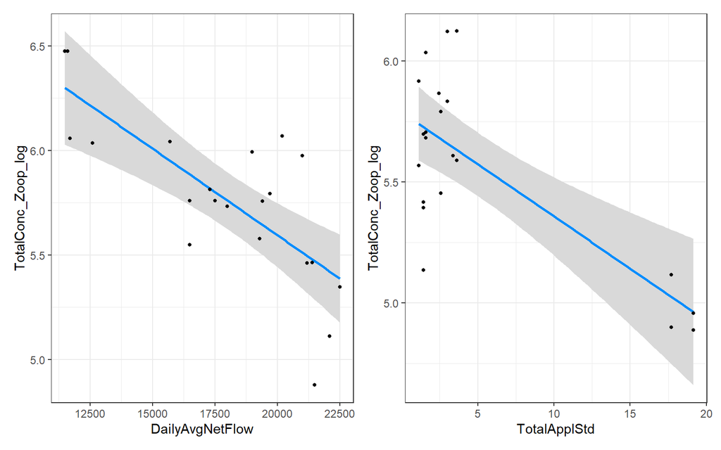

```r
plt_m_zoop_q_shr <- visreg(m_zoop_q_appl_shr_log, xvar = "DailyAvgNetFlow", gg = TRUE) +
  theme_bw() +
  geom_point(size = 1)

plt_m_zoop_appl_shr <- visreg(m_zoop_q_appl_shr_log, xvar = "TotalApplStd", gg = TRUE) +
  theme_bw() +
  geom_point(size = 1)

plt_m_zoop_shr <- plt_m_zoop_q_shr + plt_m_zoop_appl_shr
plt_m_zoop_shr
```

Total pesticide concentrations decrease significantly with flow and monthly pesticide application at the SHR station; however, the relationship with monthly pesticide application is driven by four values with the highest application.

##### Prior month application

Let’s see if the model is a better fit when we use the prior month’s application amount.

```r
m_zoop_q_appl_pr_shr <- df_zoop_shr %>%
  lm(TotalConc_Zoop ~ DailyAvgNetFlow + TotalApplStd_lag1, data = .)
```

Plot the diagnostics

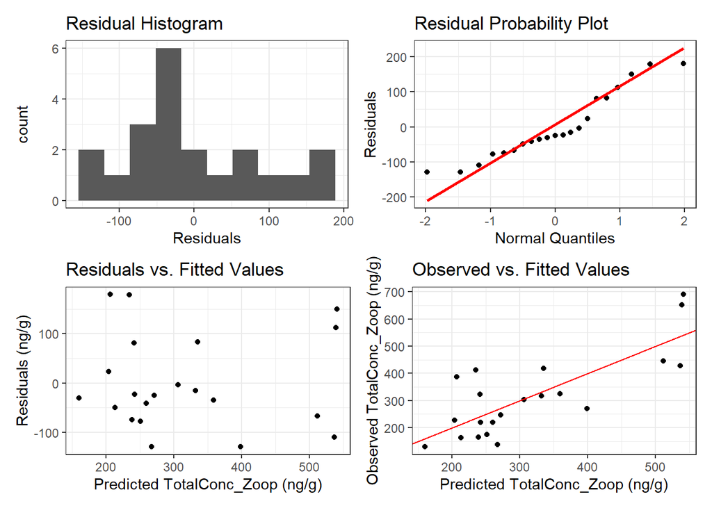

```r
df_zoop_shr %>% plot_model_diag(
  TotalConc_Zoop,
  "ng/g",
  m_zoop_q_appl_pr_shr,
  bins = 10
)
```

```r
shapiro.test(m_zoop_q_appl_pr_shr$residuals)
```

```
##
##  Shapiro-Wilk normality test
##
## data:  m_zoop_q_appl_pr_shr$residuals
## W = 0.91528, p-value = 0.06986
```

The residuals deviate from a normal distribution according to visual inspection. We’ll re-run the model using the natural log transformation.

```r
m_zoop_q_appl_pr_shr_log <- df_zoop_shr %>%
  lm(TotalConc_Zoop_log ~ DailyAvgNetFlow + TotalApplStd_lag1, data = .)
```

Plot the diagnostics

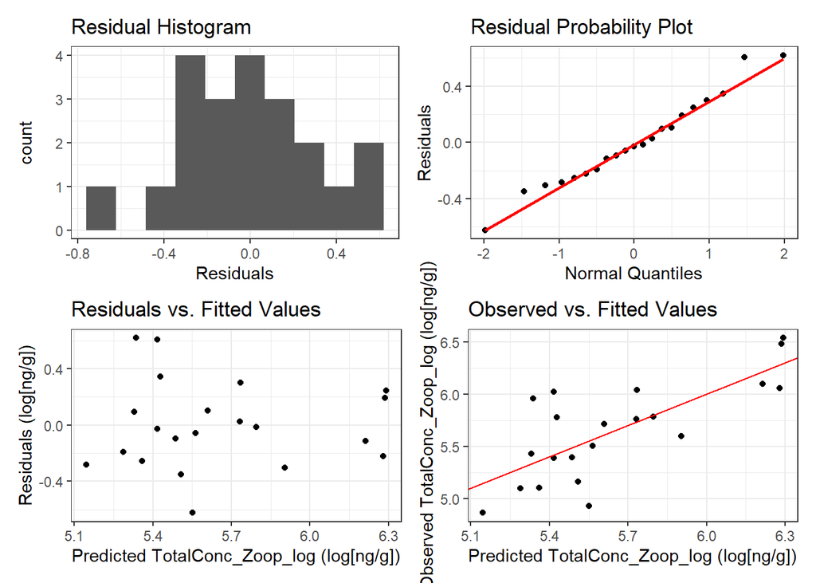

```r
df_zoop_shr %>% plot_model_diag(
  TotalConc_Zoop_log,
  "ng/g",
  m_zoop_q_appl_pr_shr_log,
  trans = "log",
  bins = 10
)
```

```r
shapiro.test(m_zoop_q_appl_pr_shr_log$residuals)
```

```
##
##  Shapiro-Wilk normality test
##
## data:  m_zoop_q_appl_pr_shr_log$residuals
## W = 0.97348, p-value = 0.8082
```

The model diagnostics look pretty good with the log-transformed values, so we’ll take a closer look at this model.

```r
summary(m_zoop_q_appl_pr_shr_log)
```

```
##
## Call:
## lm(formula = TotalConc_Zoop_log ~ DailyAvgNetFlow + TotalApplStd_lag1,
##     data = .)
##
## Residuals:
##      Min       1Q   Median       3Q      Max
## -0.62399 -0.22201 -0.02841  0.19220  0.61989
##
## Coefficients:
##                     Estimate Std. Error t value Pr(>|t|)
## (Intercept)        7.136e+00  3.768e-01  18.935 2.47e-13 ***
## DailyAvgNetFlow   -7.119e-05  2.066e-05  -3.446  0.00288 **
## TotalApplStd_lag1 -1.588e-02  5.192e-03  -3.058  0.00677 **
## ---
## Signif. codes:  0 '***' 0.001 '**' 0.01 '*' 0.05 '.' 0.1 ' ' 1
##
## Residual standard error: 0.3284 on 18 degrees of freedom
## Multiple R-squared:  0.5653, Adjusted R-squared:  0.517
## F-statistic:  11.7 on 2 and 18 DF,  p-value: 0.0005545
```

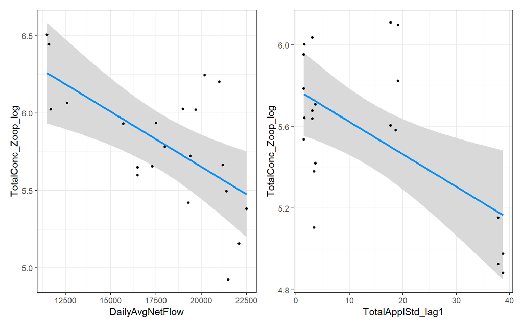

```r
plt_m_zoop_q_pr_shr <- visreg(m_zoop_q_appl_pr_shr_log, xvar = "DailyAvgNetFlow", gg = TRUE) +
  theme_bw() +
  geom_point(size = 1)

plt_m_zoop_appl_pr_shr <- visreg(m_zoop_q_appl_pr_shr_log, xvar = "TotalApplStd_lag1", gg = TRUE) +
  theme_bw() +
  geom_point(size = 1)

plt_m_zoop_pr_shr <- plt_m_zoop_q_pr_shr + plt_m_zoop_appl_pr_shr
plt_m_zoop_pr_shr
```

Again, total pesticide concentrations decrease significantly with flow and monthly pesticide application at the SHR station using the prior month’s application. The relationship with monthly pesticide application isn’t as susceptible to leverage by values with the highest application.

##### Model selection

Let’s take a look at AIC and BIC values to see which model is better.

```r
AIC(m_zoop_q_appl_shr_log, m_zoop_q_appl_pr_shr_log)
```

```
##                          df       AIC
## m_zoop_q_appl_shr_log     4  9.768586
## m_zoop_q_appl_pr_shr_log  4 17.586844
```

```r
BIC(m_zoop_q_appl_shr_log, m_zoop_q_appl_pr_shr_log)
```

```
##                          df      BIC
## m_zoop_q_appl_shr_log     4 13.94668
## m_zoop_q_appl_pr_shr_log  4 21.76493
```

Both AIC and BIC prefer the model with the current month’s pesticide application.

#### STTD

Next, we’ll look at STTD

##### Current month application

```r
df_zoop_sttd <- df_zoop %>% filter(Station == "STTD")

m_zoop_q_appl_sttd <- df_zoop_sttd %>%
  lm(TotalConc_Zoop ~ DailyAvgNetFlow + TotalApplStd, data = .)
```

Plot the diagnostics

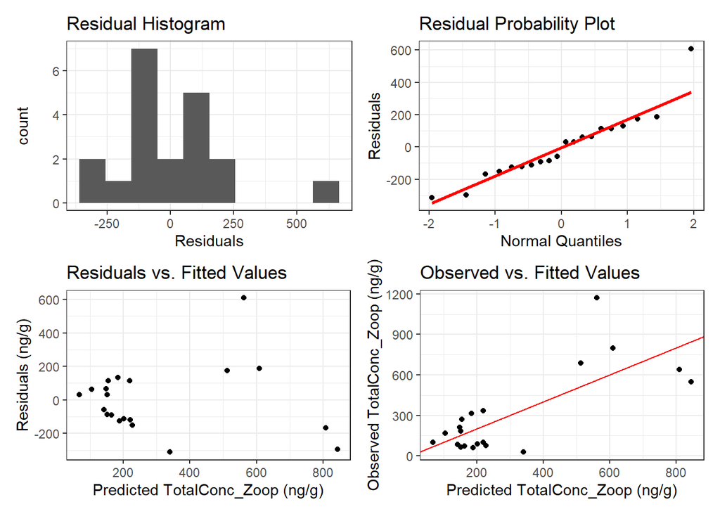

```r
df_zoop_sttd %>% plot_model_diag(
  TotalConc_Zoop,
  "ng/g",
  m_zoop_q_appl_sttd,
  bins = 10
)
```

```r
shapiro.test(m_zoop_q_appl_sttd$residuals)
```

```
##
##  Shapiro-Wilk normality test
##
## data:  m_zoop_q_appl_sttd$residuals
## W = 0.90656, p-value = 0.05484
```

The residuals deviate from a normal distribution according to visual inspection. We’ll re-run the model using the natural log transformation.

```r
m_zoop_q_appl_sttd_log <- df_zoop_sttd %>%
  lm(TotalConc_Zoop_log ~ DailyAvgNetFlow + TotalApplStd, data = .)
```

Plot the diagnostics

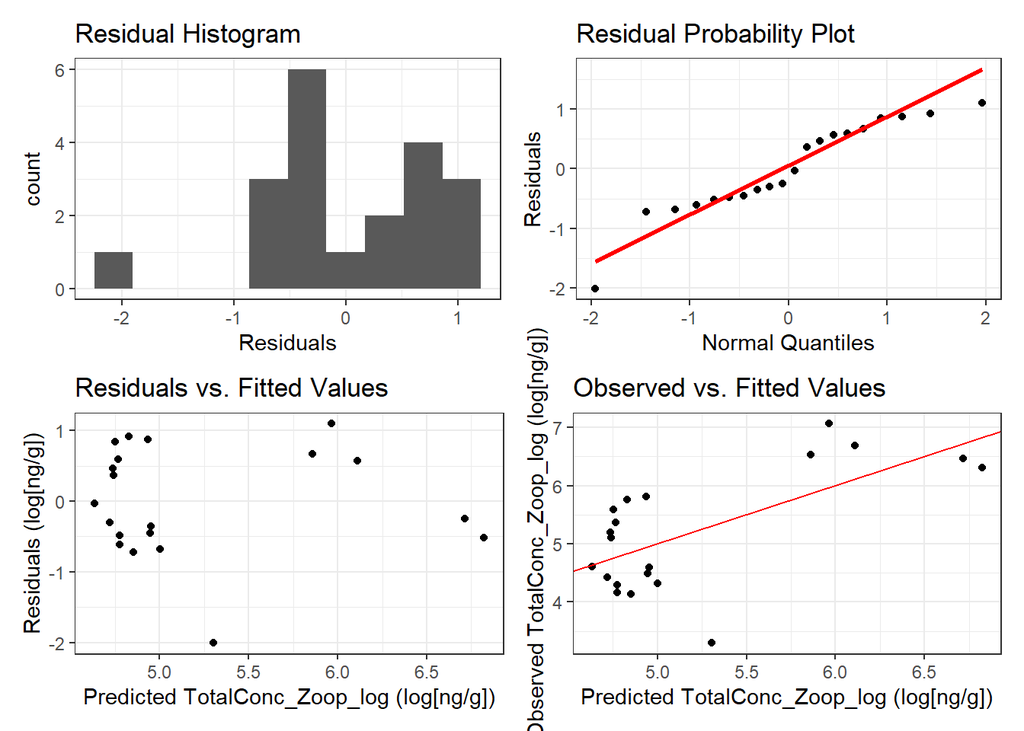

```r
df_zoop_sttd %>% plot_model_diag(
  TotalConc_Zoop_log,
  "ng/g",
  m_zoop_q_appl_sttd_log,
  trans = "log",
  bins = 10
)
```

```r
shapiro.test(m_zoop_q_appl_sttd_log$residuals)
```

```
##
##  Shapiro-Wilk normality test
##
## data:  m_zoop_q_appl_sttd_log$residuals
## W = 0.92061, p-value = 0.1018
```

The natural log transformation may be too strong. We’ll re-run the model using the square root-transformation.

```r
m_zoop_q_appl_sttd_sqrt <- df_zoop_sttd %>%
  lm(TotalConc_Zoop_sqrt ~ DailyAvgNetFlow + TotalApplStd, data = .)
```

Plot the diagnostics

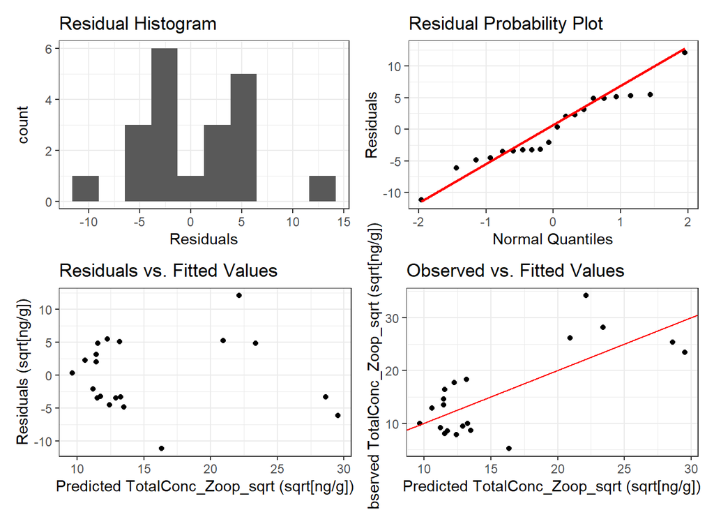

```r
df_zoop_sttd %>% plot_model_diag(
  TotalConc_Zoop_sqrt,
  "ng/g",
  m_zoop_q_appl_sttd_sqrt,
  trans = "sqrt",
  bins = 10
)
```

```r
shapiro.test(m_zoop_q_appl_sttd_sqrt$residuals)
```

```
##
##  Shapiro-Wilk normality test
##
## data:  m_zoop_q_appl_sttd_sqrt$residuals
## W = 0.95259, p-value = 0.4081
```

The model diagnostics look best with this model, so we’ll take a closer look at this one.

```r
summary(m_zoop_q_appl_sttd_sqrt)
```

```
##
## Call:
## lm(formula = TotalConc_Zoop_sqrt ~ DailyAvgNetFlow + TotalApplStd,
##     data = .)
##
## Residuals:
##      Min       1Q   Median       3Q      Max
## -11.1552  -3.4770  -0.8651   4.8538  12.0845
##
## Coefficients:
##                  Estimate Std. Error t value Pr(>|t|)
## (Intercept)     13.760969   1.920517   7.165 1.58e-06 ***
## DailyAvgNetFlow  0.025096   0.005822   4.311 0.000474 ***
## TotalApplStd    -0.021261   0.074230  -0.286 0.778020
## ---
## Signif. codes:  0 '***' 0.001 '**' 0.01 '*' 0.05 '.' 0.1 ' ' 1
##
## Residual standard error: 5.754 on 17 degrees of freedom
## Multiple R-squared:  0.5549, Adjusted R-squared:  0.5025
## F-statistic:  10.6 on 2 and 17 DF,  p-value: 0.001028
```

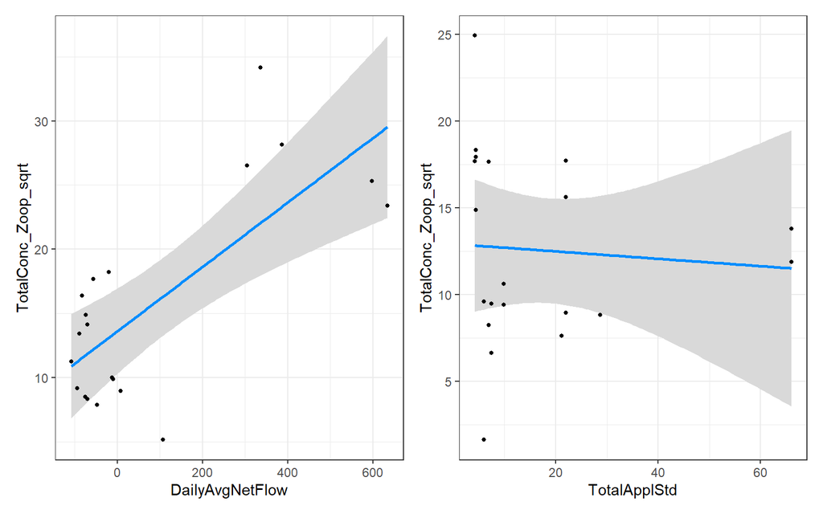

```r
plt_m_zoop_q_sttd <- visreg(m_zoop_q_appl_sttd_sqrt, xvar = "DailyAvgNetFlow", gg = TRUE) +
  theme_bw() +
  geom_point(size = 1)

plt_m_zoop_appl_sttd <- visreg(m_zoop_q_appl_sttd_sqrt, xvar = "TotalApplStd", gg = TRUE) +
  theme_bw() +
  geom_point(size = 1)

plt_m_zoop_sttd <- plt_m_zoop_q_sttd + plt_m_zoop_appl_sttd
plt_m_zoop_sttd
```

Total pesticide concentrations increase significantly with flow at the STTD station, but there is no relationship between concentration and monthly pesticide application.

##### Prior month application

Let’s see if the model is a better fit when we use the prior month’s application amount.

```r
m_zoop_q_appl_pr_sttd <- df_zoop_sttd %>%
  lm(TotalConc_Zoop ~ DailyAvgNetFlow + TotalApplStd_lag1, data = .)
```

Plot the diagnostics

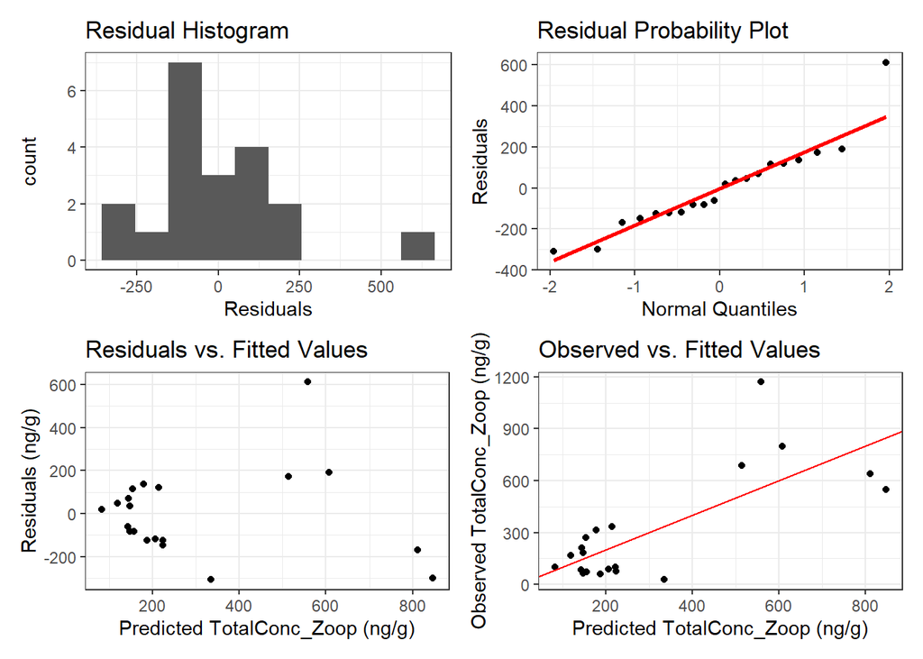

```r
df_zoop_sttd %>% plot_model_diag(
  TotalConc_Zoop,
  "ng/g",
  m_zoop_q_appl_pr_sttd,
  bins = 10
)
```

```r
shapiro.test(m_zoop_q_appl_pr_sttd$residuals)
```

```
##
##  Shapiro-Wilk normality test
##
## data:  m_zoop_q_appl_pr_sttd$residuals
## W = 0.90557, p-value = 0.05251
```

The residuals deviate from a normal distribution according to visual inspection. We’ll re-run the model using the natural log transformation.

```r
m_zoop_q_appl_pr_sttd_log <- df_zoop_sttd %>%
  lm(TotalConc_Zoop_log ~ DailyAvgNetFlow + TotalApplStd_lag1, data = .)
```

Plot the diagnostics

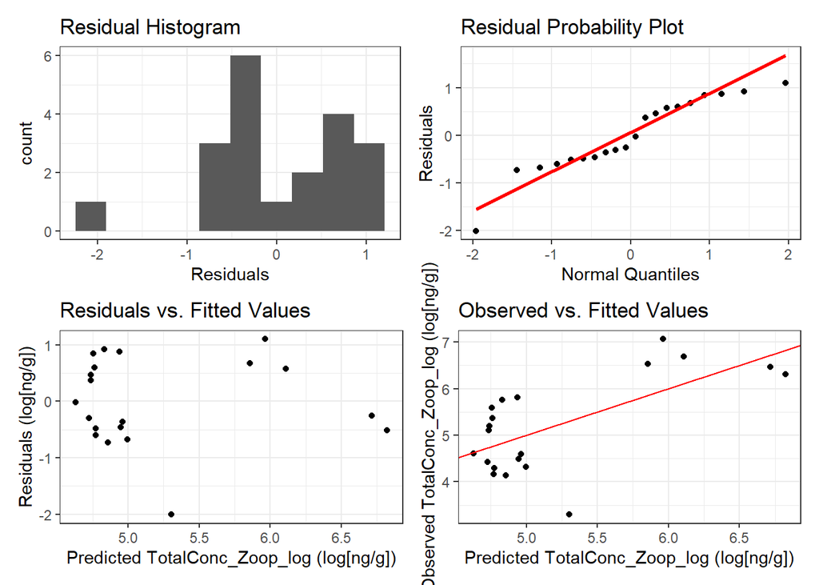

```r
df_zoop_sttd %>% plot_model_diag(
  TotalConc_Zoop_log,
  "ng/g",
  m_zoop_q_appl_pr_sttd_log,
  trans = "log",
  bins = 10
)
```

```r
shapiro.test(m_zoop_q_appl_pr_sttd_log$residuals)
```

```
##
##  Shapiro-Wilk normality test
##
## data:  m_zoop_q_appl_pr_sttd_log$residuals
## W = 0.92017, p-value = 0.09981
```

Again, the natural log transformation may be too strong. We’ll re-run the model using the square root-transformation.

```r
m_zoop_q_appl_pr_sttd_sqrt <- df_zoop_sttd %>%
  lm(TotalConc_Zoop_sqrt ~ DailyAvgNetFlow + TotalApplStd_lag1, data = .)
```

Plot the diagnostics

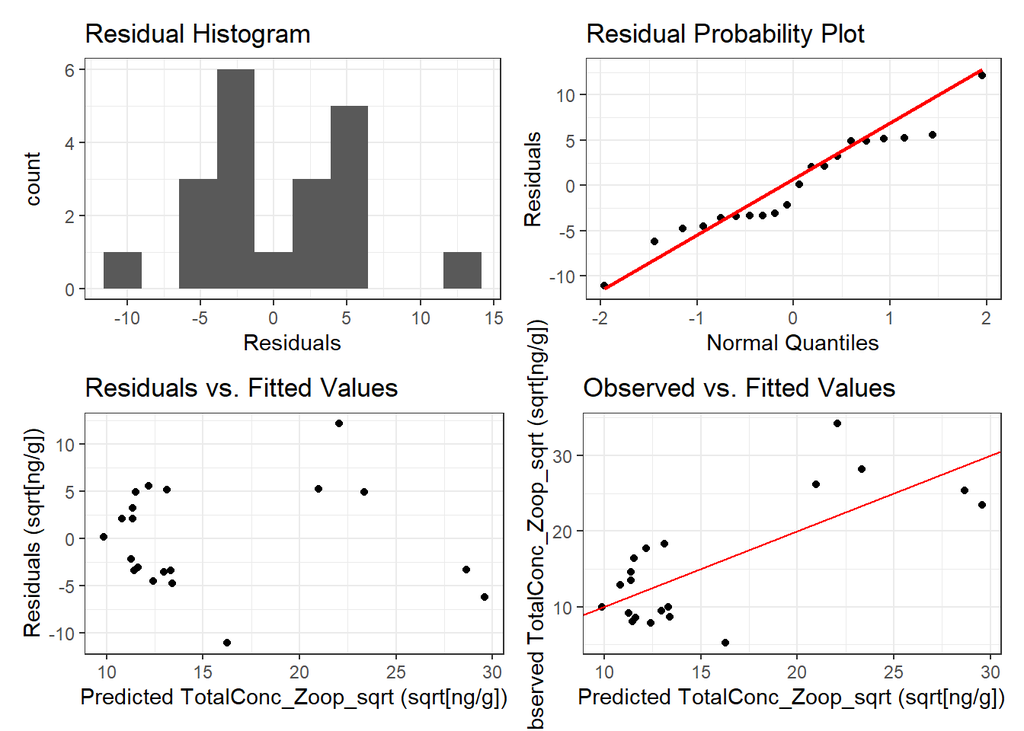

```r
df_zoop_sttd %>% plot_model_diag(
  TotalConc_Zoop_sqrt,
  "ng/g",
  m_zoop_q_appl_pr_sttd_sqrt,
  trans = "sqrt",
  bins = 10
)
```

```r
shapiro.test(m_zoop_q_appl_pr_sttd_sqrt$residuals)
```

```
##
##  Shapiro-Wilk normality test
##
## data:  m_zoop_q_appl_pr_sttd_sqrt$residuals
## W = 0.9525, p-value = 0.4067
```

The model diagnostics look best with this model, so we’ll take a closer look at this one.

```r
summary(m_zoop_q_appl_pr_sttd_sqrt)
```

```
##
## Call:
## lm(formula = TotalConc_Zoop_sqrt ~ DailyAvgNetFlow + TotalApplStd_lag1,
##     data = .)
##
## Residuals:
##     Min      1Q  Median      3Q     Max
## -11.078  -3.453  -1.004   4.880  12.143
##
## Coefficients:
##                    Estimate Std. Error t value Pr(>|t|)
## (Intercept)       13.666197   1.855055   7.367  1.1e-06 ***
## DailyAvgNetFlow    0.025367   0.005649   4.490 0.000322 ***
## TotalApplStd_lag1 -0.006553   0.028126  -0.233 0.818554
## ---
## Signif. codes:  0 '***' 0.001 '**' 0.01 '*' 0.05 '.' 0.1 ' ' 1
##
## Residual standard error: 5.759 on 17 degrees of freedom
## Multiple R-squared:  0.5542, Adjusted R-squared:  0.5017
## F-statistic: 10.57 on 2 and 17 DF,  p-value: 0.001042
```

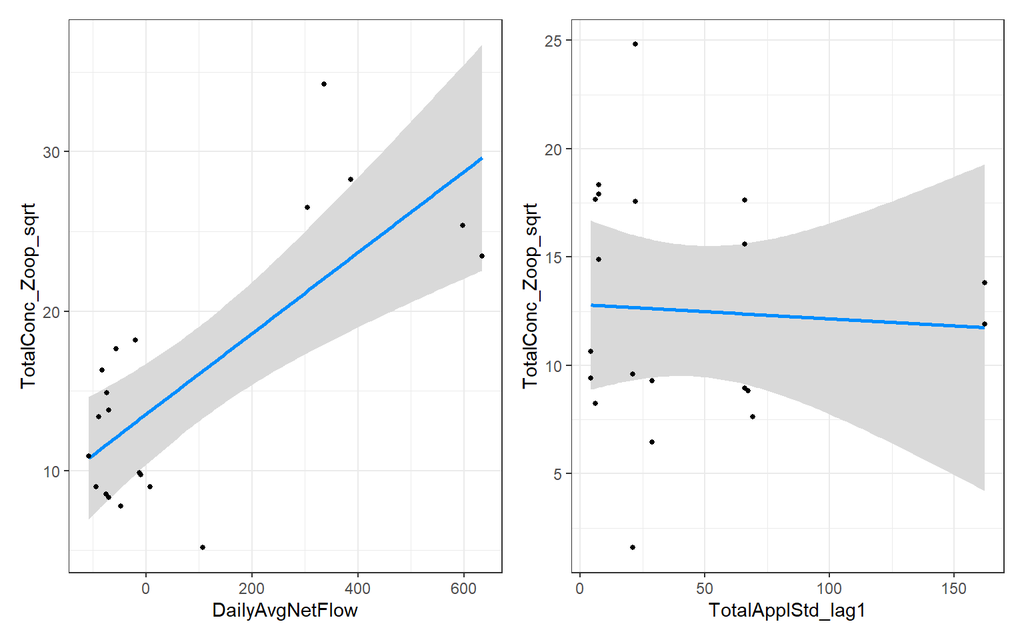

```r
plt_m_zoop_q_pr_sttd <- visreg(m_zoop_q_appl_pr_sttd_sqrt, xvar = "DailyAvgNetFlow", gg = TRUE) +
  theme_bw() +
  geom_point(size = 1)

plt_m_zoop_appl_pr_sttd <- visreg(m_zoop_q_appl_pr_sttd_sqrt, xvar = "TotalApplStd_lag1", gg = TRUE) +
  theme_bw() +
  geom_point(size = 1)

plt_m_zoop_pr_sttd <- plt_m_zoop_q_pr_sttd + plt_m_zoop_appl_pr_sttd
plt_m_zoop_pr_sttd
```

The results are the same with this model.

##### Model selection

Let’s take a look at AIC and BIC values to see which model is better.

```r
AIC(m_zoop_q_appl_sttd_sqrt, m_zoop_q_appl_pr_sttd_sqrt)
```

```
##                            df      AIC
## m_zoop_q_appl_sttd_sqrt     4 131.5035
## m_zoop_q_appl_pr_sttd_sqrt  4 131.5360
```

```r
BIC(m_zoop_q_appl_sttd_sqrt, m_zoop_q_appl_pr_sttd_sqrt)
```

```
##                            df      BIC
## m_zoop_q_appl_sttd_sqrt     4 135.4865
## m_zoop_q_appl_pr_sttd_sqrt  4 135.5190
```

The AIC and BIC values are nearly identical between models with both metrics giving a slight edge to the model with the current month’s pesticide application.

### Model with Station and Year

Next, we’ll create a linear model of the zooplankton concentrations as a function of the interaction between station and year. We’ll start with the original concentration values, but we may need to transform them. This model will allow us to examine:

1. If the interaction between station and year isn’t significant, whether total pesticide concentrations in zooplankton are significantly different among stations or years (main effects).
2. If the interaction is significant, whether total pesticide concentrations in zooplankton are significantly different among stations for each year or among years for each station.

#### With interaction

```r
m_zoop_sta_yr <- df_zoop %>%
  lm(TotalConc_Zoop ~ Station * Year, data = .)
```

Plot the diagnostics

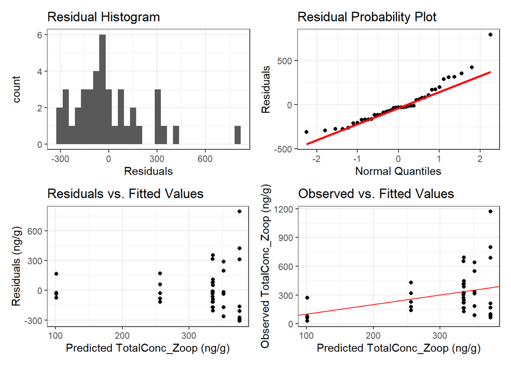

```r
df_zoop %>% plot_model_diag(
  TotalConc_Zoop,
  "ng/g",
  m_zoop_sta_yr
)
```

```r
shapiro.test(m_zoop_sta_yr$residuals)
```

```
##
##  Shapiro-Wilk normality test
##
## data:  m_zoop_sta_yr$residuals
## W = 0.90768, p-value = 0.002817
```

The residuals deviate from a normal distribution according to the Shapiro-Wilk normality test and visual inspection. Also, the variance among groups isn’t consistent. We’ll re-run the model using the natural log of the concentration values.

```r
m_zoop_sta_yr_log <- df_zoop %>%
  lm(TotalConc_Zoop_log ~ Station * Year, data = .)
```

Plot the diagnostics

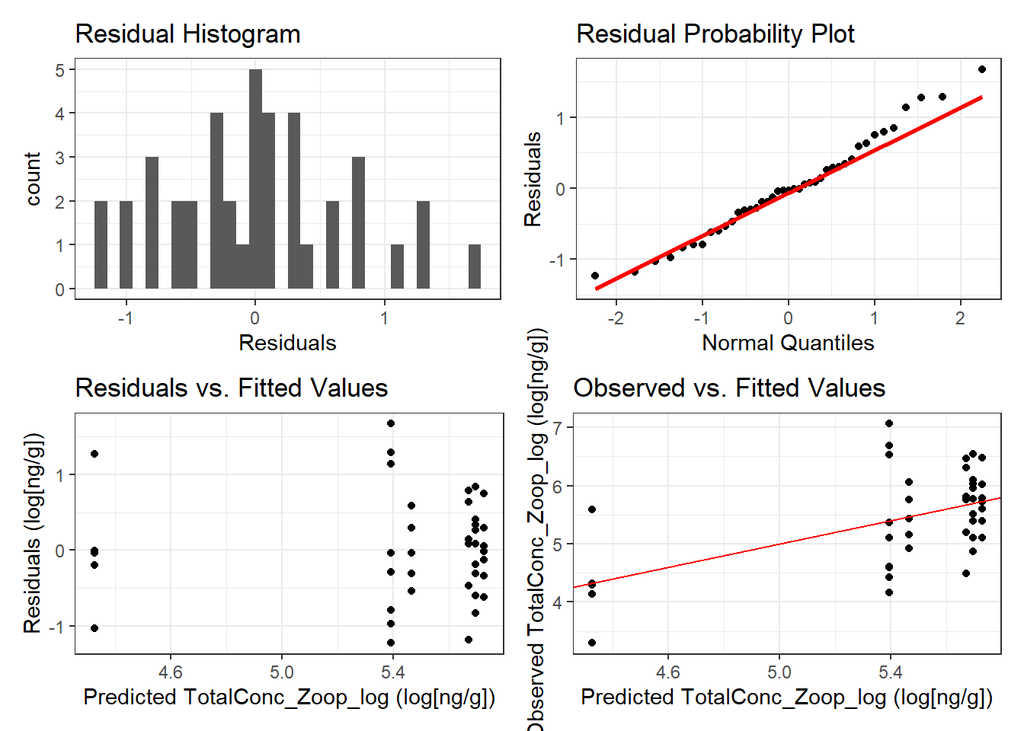

```r
df_zoop %>% plot_model_diag(
  TotalConc_Zoop_log,
  "ng/g",
  m_zoop_sta_yr_log,
  trans = "log"
)
```

```r
shapiro.test(m_zoop_sta_yr_log$residuals)
```

```
##
##  Shapiro-Wilk normality test
##
## data:  m_zoop_sta_yr_log$residuals
## W = 0.97934, p-value = 0.6506
```

This is much better than the model with original values. Let’s take a look at the Anova table using type 3 sum of squares for the model using natural log transformation.

##### ANOVA table

```r
Anova(m_zoop_sta_yr_log, type = 3, contrasts = list(topic = contr.sum, sys = contr.sum))
```

```
## Anova Table (Type III tests)
##
## Response: TotalConc_Zoop_log
##               Sum Sq Df  F value  Pr(>F)
## (Intercept)  149.373  1 272.8261 < 2e-16 ***
## Station        3.248  1   5.9332 0.02009 *
## Year           0.230  2   0.2101 0.81154
## Station:Year   1.887  2   1.7230 0.19334
## Residuals     19.163 35
## ---
## Signif. codes:  0 '***' 0.001 '**' 0.01 '*' 0.05 '.' 0.1 ' ' 1
```

Well, the interaction term is not significant which means we can take a look at the main effects. Before we do this, we’ll remove the interaction from the model since it’s not necessary. We’ll stick with the model using natural log transformation.

#### Without interaction

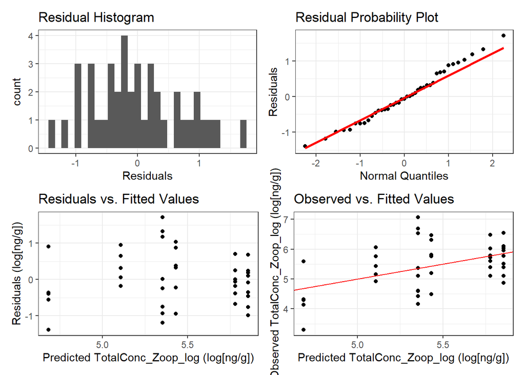

```r
m_zoop_sta_yr_log2 <- df_zoop %>%
  lm(TotalConc_Zoop_log ~ Station + Year, data = .)

df_zoop %>% plot_model_diag(
  TotalConc_Zoop_log,
  "ng/g",
  m_zoop_sta_yr_log2,
  trans = "log"
)
```

```r
shapiro.test(m_zoop_sta_yr_log2$residuals)
```

```
##
##  Shapiro-Wilk normality test
##
## data:  m_zoop_sta_yr_log2$residuals
## W = 0.98495, p-value = 0.8542
```

The diagnostics still look good with this model. Let’s take a look at the Anova table using type 2 sum of squares because of the unbalanced design.

##### ANOVA table

```r
Anova(m_zoop_sta_yr_log2, type = 2)
```

```
## Anova Table (Type II tests)
##
## Response: TotalConc_Zoop_log
##            Sum Sq Df F value  Pr(>F)
## Station    1.8028  1  3.1690 0.08326 .
## Year       3.8276  2  3.3641 0.04546 *
## Residuals 21.0492 37
## ---
## Signif. codes:  0 '***' 0.001 '**' 0.01 '*' 0.05 '.' 0.1 ' ' 1
```

The main effect of station is not significant (p = 0.083) meaning that total pesticide concentrations in zooplankton don’t differ between SHR and STTD. However, the main effect of Year is significant, so we can take a look at the pairwise contrasts to see how concentrations differ among the years. We’ll also take a look at the pairwise contrasts for station since it is close to significant.

##### Contrasts

```r
# Contrasts for Year main effect
em_zoop_yr <- emmeans(m_zoop_sta_yr_log2, specs = "Year")
pairs(em_zoop_yr)
```

```
##  contrast            estimate    SE df t.ratio p.value
##  Year2017 - Year2018  -0.6700 0.304 37  -2.201  0.0842
##  Year2017 - Year2019  -0.7474 0.309 37  -2.420  0.0525
##  Year2018 - Year2019  -0.0774 0.274 37  -0.283  0.9570
##
## Results are averaged over the levels of: Station
## P value adjustment: tukey method for comparing a family of 3 estimates
```

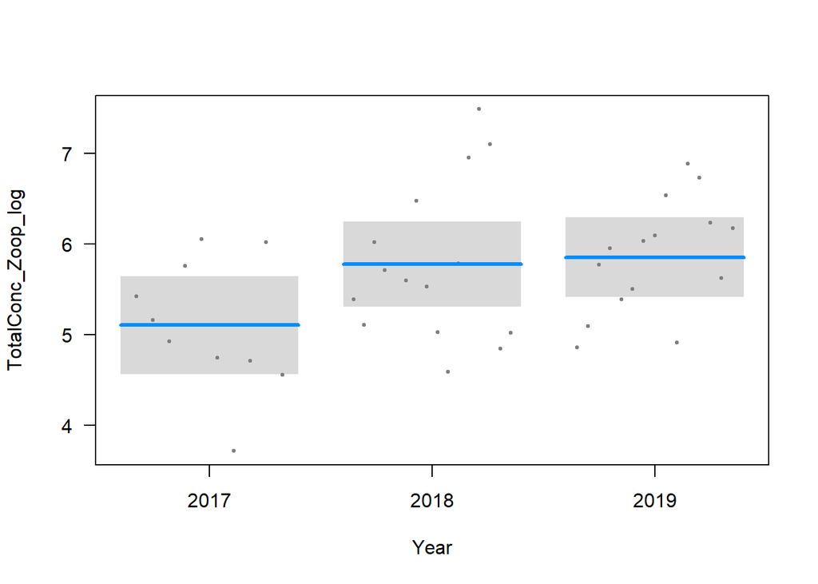

```r
visreg(m_zoop_sta_yr_log2, xvar = "Year")
```

```r
# Contrasts for Station main effect
em_zoop_sta <- emmeans(m_zoop_sta_yr_log2, specs = "Station")
pairs(em_zoop_sta)
```

```
##  contrast   estimate    SE df t.ratio p.value
##  SHR - STTD    0.424 0.238 37   1.780  0.0833
##
## Results are averaged over the levels of: Year
```

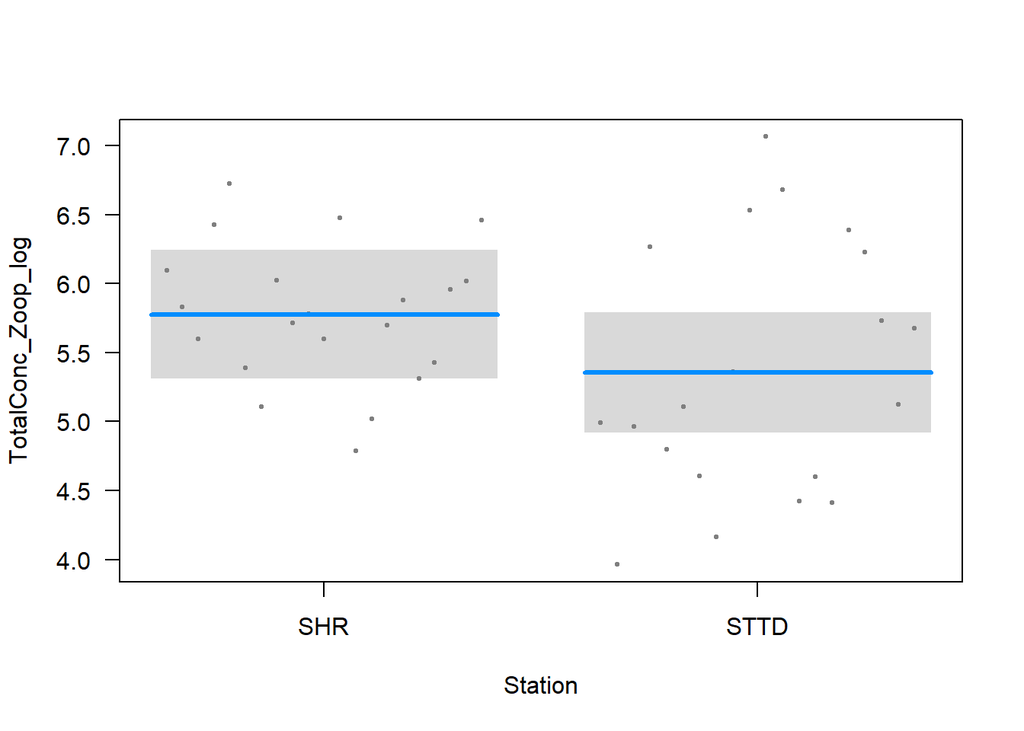

```r
visreg(m_zoop_sta_yr_log2, xvar = "Station")
```

Pairwise tests indicate that total pesticide concentration in zooplankton in 2019 is marginally significantly higher than 2017, but the p-value is 0.053. Also, the p-value isn’t significant, but SHR is slightly higher than STTD.